# Comparing Two Means

Analysing Data Week 6

Dr Jennifer Mankin

Click for slides

## Overview of the Next Weeks

- Week 5: Measures of Association
- TODAY: Comparing Two Means
- Week 7: Lab Report Writing
- Week 8: The Linear Model

## Overview of Today’s Topics

- Important Ideas
  - The *t*-distribution
- Comparing Two Means
  - Study Design
  - Logic of *t*-tests
  - Using and reporting *t*-tests
  - A quick look at the bigger picture (`lm()`)

## Important Ideas

- You heard a lot from Milan about distributions, especially *t*
  - Good news! That’s all about to be really important
  - Still a bit lost? Revise Milan’s lectures and the Week 4 tutorial

## Red Study: Design

- Conceptual hypothesis: Does colour influence attractiveness?
- Operationalisation:
  - Colour: participants saw one of two pictures in a frame
    - Control = white frame; experimental = red frame
  - Attractiveness: ratings of 1 - 9 on three questions:
    - How attractive do you think this person is?
    - How pleasant is this person to look at?
    - If I were to meet the person in this picture face to face, I would think he is attractive.
    - Answers averaged to get a composite score
- Stop and discuss:
  - What variables will we have? How are they measured?
  - Which is the **predictor** and which is the **outcome**?
  - How could you state the operational hypothesis of this study?
- Conceptual hypothesis: Does colour influence attractiveness?
- What variables will we have? How are they measured?
  - Colour: Independent categorical variable
    - Two levels: `red` (experimental) and `white` (control)
    - Predictor: the thing we are manipulating
  - Attractiveness: continuous variable
    - Values on a scale from 1 - 9 (higher = more attractive)
    - Outcome: the thing that changes depending on our manipulation
- Conceptual hypothesis: Does colour influence attractiveness?
- How could you state the operational hypothesis of this study?
- Does viewing a different colour frame around an image of a moderately attractive man influence the mean ratings of his attractiveness?

## Red Study: Data

The (simulated) data might look something like this:

- `group`: Experimental colour condition, either `control` (white) or `experimental` (red)
- `attract`: Mean of three attractiveness ratings

```
# A tibble: 150 x 7
   id_code years group   item_1 item_2 item_3 attract
   <fct>   <chr> <fct>    <dbl>  <dbl>  <dbl>   <dbl>
 1 SAUU    21    control      6      9      5    6.67
 2 JVNJ    16    control      6      5      5    5.33
 3 GIOU    19    control      6      6      5    5.67
 4 EIYN    23    control      8      6      8    7.33
 5 EEBJ    16    control      5      6      4    5
 6 YLOA    21    control      8      5      8    7
 7 TCFJ    19    control      5      6      2    4.33
 8 JFOT    20    control      6      6      3    5
 9 TZLY    23    control      6      6      3    5
10 WFYH    22    control      7      4      6    5.67
# ... with 140 more rows
```

## Overall Distribution

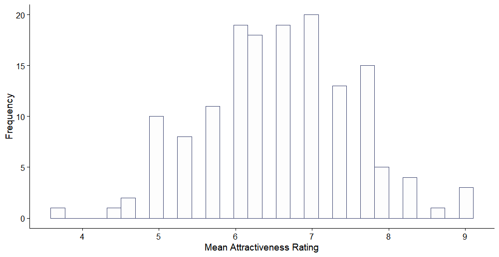

## By Groups

- Are the means of the two groups different?
- Are they different enough for us to believe that they **come from different populations**?

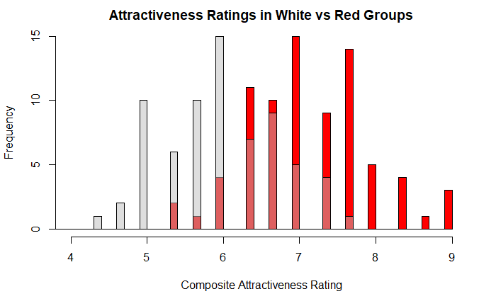

## Red Study: Asking Questions

- If they are different enough:
  - We conclude that people in the two different experimental conditions represent samples from **different populations**, which have different mean attractiveness ratings
  - That is: colour does make a difference in attractiveness ratings
- If they are not different enough:
  - We conclude that the people in the two different experimental conditions represent samples from **the same population**, which has a single mean attractiveness ratings
  - That is: colour makes no difference to attractiveness ratings

## Recipe for Statistical Testing

- As always, we will need:
  - Data
  - A test statistic
  - The distribution of that test statistic
  - The probability *p* of finding a test statistic as large as the one we have (or larger) if the null hypothesis is true

## Red Study: Getting Answers

- Are the means in the red vs white groups different enough for us to believe that they **come from different populations**?
  - How different are they?
- Very simply: *M*<sub>red</sub> - *M*<sub>white</sub> = 7.14 - 5.95 = 1.19 rating points

## Red Study: The Means

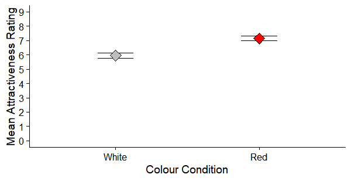

## Red Study: Differences in Means

- The value 1.19 tells us how different our two sample means were in our experiment
- Is this a big difference, compared to how different we might expect for any two sample means **from the same population**?

## Red Study: SE of Differences

- Imagine we took two samples from a population and calculated their means, and then found the **difference** between those means
- The standard error of the distribution of those mean differences would tell us how different any two sample means from the same population are likely to be
  - Very small differences in means will be quite common
  - Very large differences in means will be quite unlikely
- If the mean difference we find is very unlikely to occur, then it may be that the two means do not come from the same population

## Red Study: Can You Hear Me Now?

- Think of a **signal-to-noise ratio**
  - Signal: the difference in sample means
  - Noise: the error, here the standard error of the difference between sample means
- The bigger the signal is compared to the noise, the less likely it is to actually just be noise itself!
- Mathematically, we can represent this by signal/noise

## Red Study: Deja Vu

- We want to know how big the difference in means is compared to the standard error of the differences in means
- If this sounds familiar: we’ve seen this before!
  - As explained in [Tutorial 4](https://mivalek.github.io/adata/tut/tut_05_stats_fundamentals.html) it is **exactly** this scenario that produces the *t*-distribution
  - See An Adventure in Statistics chapter 15 for the calculation of *t*

## Red Study: Using *t*

- *t* is the difference in sample means compared to the standard error of the differences in means
  - The larger the value of *t*, the bigger the difference between sample means is compared to the error
    - i.e. bigger signal-to-noise ratio
  - Check whether *t* is “large enough” using its distribution
- We can ask R to calculate *t* for us and get the associated *p*-value

## Red Study: the *t*-test

```r
elliot_t <- elliot %>%
  t.test(attract ~ group, ., alternative = "two.sided", paired = F, var.equal = T)
elliot_t

    Two Sample t-test

data:  attract by group
t = -9.092, df = 148, p-value = 5.924e-16
alternative hypothesis: true difference in means is not equal to 0
95 percent confidence interval:
 -1.4497190 -0.9320484
sample estimates:
     mean in group control mean in group experimental
                  5.948357                   7.139241
```

## Red Study: Interpretation

- Our value for *t* is -9.09
  - The difference between our sample means of -1.19 was 9.09 times greater than the standard error of the difference in means
- Unsurprisingly, that value is very unlikely to occur if in fact the true difference in means is 0 (*p* < .001)
- Conclusion: it is unlikely that these sample means come from the same population
  - ie the null hypothesis may not be true

```
    Two Sample t-test

data:  attract by group
t = -9.092, df = 148, p-value = 5.924e-16
alternative hypothesis: true difference in means is not equal to 0
95 percent confidence interval:
 -1.4497190 -0.9320484
sample estimates:
     mean in group control mean in group experimental
                  5.948357                   7.139241
```

- Report: “There was a significant difference in the mean attractiveness ratings of the red vs white colour groups (*M*<sub>diff</sub> = -1.19, 95% CI [-1.45, -0.93], *t*(148) = -9.09), *p* < .001).”

## Red Study: Going Further

- Thus far we’ve been looking at an independent-samples *t* test
  - There are different people in the two groups (e.g. red and white)
- What if you have the **same** people in both groups?

## Repeated Measures

- Imagine participants viewed both the white and the red pictures
  - Half saw the red picture first, then the white picture
  - The other half saw white first then red
- After each picture, they gave attractiveness ratings as before
- This is a **repeated measures** design

```r
elliot_t_paired <- elliot_paired %>%
  t.test(attract ~ condition, ., alternative = "two.sided", paired = T, var.equal = T)
elliot_t_paired

    Paired t-test

data:  attract by condition
t = -8.578, df = 70, p-value = 1.575e-12
alternative hypothesis: true difference in means is not equal to 0
95 percent confidence interval:
 -1.5218273 -0.9476563
sample estimates:
mean of the differences
              -1.234742
```

- Report: “There was a significant difference in mean attractiveness ratings for the red vs white conditions (*M*<sub>diff</sub> = -1.23, 95% CI [-1.52, -0.95], *t*(70) = -8.58), *p* < .001).”

## Red Study: Summary

- Design: Means of attractiveness ratings in two independent conditions (red vs white)
- Results: Ratings were significantly different in the two conditions
  - *t* quantifies the size of the difference in means relative to the error
  - Signal-to-noise ratio
- **IMPORTANT**: Use an independent (not paired) test in your report!

## It’s All Greek (And Latin) To Me

- This is a lot of test statistics and random letters to remember
  - *t*, *r*, *χ*<sup>2</sup>…
  - Each with their own type of data they can and can’t use!
- Wouldn’t it be great if we had just one statistical test that did everything?

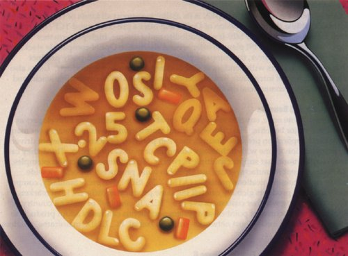

alphabet soup

## *t* and *r*

- Remember from last week: the *p*-value from *r* comes from the *t*-distribution
- This means **we can change *t* into *r*** (and vice versa!)

```r
elliot.cor <- elliot %>%
  mutate(group = as.character(group),
         group = recode(group, "control" = "0", "experimental" = "1"),
         group = as.numeric(group))

elliot_cor_test <- elliot.cor %>%
  cor.test(~ attract + group, ., alternative = "two.sided", method = "pearson")
elliot_cor_test

    Pearson's product-moment correlation

data:  attract and group
t = 9.092, df = 148, p-value = 5.924e-16
alternative hypothesis: true correlation is not equal to 0
95 percent confidence interval:
 0.4849050 0.6924709
sample estimates:
      cor
0.5986449
```

## *t* and *r*: What’s happening?

- Known as a point-biserial correlation
  - Simply means: a correlation where one of the variables is a categorical variable with two levels
  - As one variable increases (e.g. from one level to another), the other also tends to increase

## *r* and *t*: Takeaway

- *r* and *t* are two different ways of capturing the same relationship
  - *t* quantifies the difference in means between two groups
  - *r* quantifies the degree and direction of a relationship between two variables
    - One of these can be a code for two different groups!
- Sorted! …Right?
  - We can do better!

## Drawing Lines

- Let’s draw a line connecting the two group means
- Start from the mean of the `white` condition (5.95)
- Draw a straight line to the mean of the `red` condition (7.14)

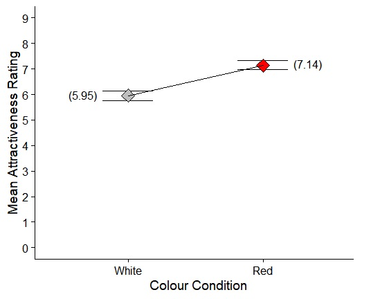

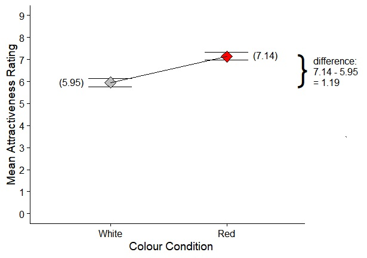

## So What?

- Isn’t this just more complication?
- This is actually an extremely important idea: the Linear Model
  - A model that takes the form of a line, like the one we just saw

## What’s So Special About LM?

- We saw earlier that *r* and *t* are two different ways of expressing the same relationship
- If *t* can be made into a linear model, **so can *r***
- So can almost **any** of the models you will learn in statistics!
  - Including *χ*<sup>2</sup>, all types of ANOVA (next term), *r*, *t*, etc.

## Quick LM Example

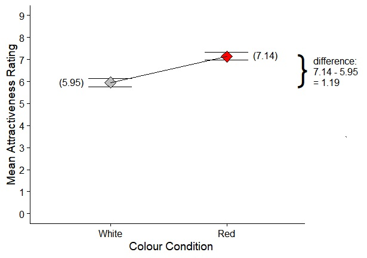

```
Call:
lm(formula = attract ~ group, data = elliot)

Coefficients:
      (Intercept)  groupexperimental
            5.948              1.191
```

## LM vs the World

- The statistical alphabet soup (*r*, *t*, *χ*<sup>2</sup>, *F*, etc.) is all ways of capturing different aspects of relationships between variables
  - All versions of the same signal-to-noise ratio for different contexts
- Why do we use them, instead of just LM?
  - (Sometimes) easier to explain/understand
  - Easier to calculate by hand (which was useful before computers!)
  - Familiar - frequently taught as separate, unrelated tests
  - The linear model can be quite complicated compared to the simple test equivalent
    - Logistic regression for *χ*<sup>2</sup>
    - Multi-level models for repeated-measures designs

## LM Takeaway

- Almost any statistical test you will learn about is a LM underneath
- It’s LM for the rest of this module, and most of next year
  - Week 8: come back to this (and other) examples in full
  - Equation of the linear model, how to use it, what it means

## Lab Report Takeaway

- You can choose either the red or green study to write your report on
  - See [Lab Report Information on Canvas](https://canvas.sussex.ac.uk/courses/9242/pages/Lab%20Report%20Information%20and%20Resources?titleize=0) for more
- If you choose the red study (Elliot et al., 2010), you should use and report the results of an independent-samples *t*-test
  - Refer to the original paper for some ideas!

## Analysis for Lab Reports

- Inspect, clean, and prepare the data for analysis
- Produce descriptives of participants (age, gender)
- Report means in each group and the results of the *t*-test
  - Use and report `t.test()`, **not** `lm()`!
  - Include at least one figure of the results
  - Will be covered in depth in the next tutorial and practical!

## Preparing for Lab Reports

- Next week’s lecture:
  - How to prepare and submit the Markdown
  - Examples of what tables and figures to include
  - How to report the results
  - How to write a good, clear, thorough discussion
- Next week’s practical and tutorial: How to run and report a *t*-test
- Week 8 practicals: Lab report guidance and writing
- Markdown template will be released along with the tutorial